# Healthcare Anomalies Detection - Using Autoencoder & iForest

- Section 1: data preparation
  - Section 1.1: Load data
  - Section 1.2: data preparation
- Section 2: Feature engineering
- Section 3: Using Autoencoder
- Section 4: Using iForest

## Section 1: Data preparation

### Section 1.1: Load Data

- Import packages and data
- Rename column
- Change data type and transfer spending amount with dollar sign into numeric
- Understand the data strcuture.

```python
import pandas as pd
import numpy as np
import matplotlib.pyplot as plt
import seaborn as sns
%matplotlib inline
```

```python
data = pd.read_csv('inpatientCharges.csv')
data.info()
```

```
<class 'pandas.core.frame.DataFrame'>
RangeIndex: 163065 entries, 0 to 163064
Data columns (total 12 columns):
 #   Column                                Non-Null Count   Dtype
---  ------                                --------------   -----
 0   DRG Definition                        163065 non-null  object
 1   Provider Id                           163065 non-null  int64
 2   Provider Name                         163065 non-null  object
 3   Provider Street Address               163065 non-null  object
 4   Provider City                         163065 non-null  object
 5   Provider State                        163065 non-null  object
 6   Provider Zip Code                     163065 non-null  int64
 7   Hospital Referral Region Description  163065 non-null  object
 8    Total Discharges                     163065 non-null  int64
 9    Average Covered Charges              163065 non-null  object
 10   Average Total Payments               163065 non-null  object
 11  Average Medicare Payments             163065 non-null  object
dtypes: int64(3), object(9)
memory usage: 14.9+ MB
```

```python
data.columns = ['DRG','Provider_Id', 'Provider_Name','Provider_StreetAddress','Provider_City',
               'Provider_State','Provider_Zipcode','Hospital_referral_region_desp',
                'Total_Discharges','Average_Covered_Charges','Average_Total_Payments',
                'Average_Medicare_Payment']
data = data.drop('Average_Covered_Charges',axis=1)
```

```python
data.head()
```

|  | DRG | Provider_Id | Provider_Name | Provider_StreetAddress | Provider_City | Provider_State | Provider_Zipcode | Hospital_referral_region_desp | Total_Discharges | Average_Total_Payments | Average_Medicare_Payment |
| --- | --- | --- | --- | --- | --- | --- | --- | --- | --- | --- | --- |
| 0 | 039 - EXTRACRANIAL PROCEDURES W/O CC/MCC | 10001 | SOUTHEAST ALABAMA MEDICAL CENTER | 1108 ROSS CLARK CIRCLE | DOTHAN | AL | 36301 | AL - Dothan | 91 | $5777.24 | $4763.73 |
| 1 | 039 - EXTRACRANIAL PROCEDURES W/O CC/MCC | 10005 | MARSHALL MEDICAL CENTER SOUTH | 2505 U S HIGHWAY 431 NORTH | BOAZ | AL | 35957 | AL - Birmingham | 14 | $5787.57 | $4976.71 |
| 2 | 039 - EXTRACRANIAL PROCEDURES W/O CC/MCC | 10006 | ELIZA COFFEE MEMORIAL HOSPITAL | 205 MARENGO STREET | FLORENCE | AL | 35631 | AL - Birmingham | 24 | $5434.95 | $4453.79 |
| 3 | 039 - EXTRACRANIAL PROCEDURES W/O CC/MCC | 10011 | ST VINCENT'S EAST | 50 MEDICAL PARK EAST DRIVE | BIRMINGHAM | AL | 35235 | AL - Birmingham | 25 | $5417.56 | $4129.16 |
| 4 | 039 - EXTRACRANIAL PROCEDURES W/O CC/MCC | 10016 | SHELBY BAPTIST MEDICAL CENTER | 1000 FIRST STREET NORTH | ALABASTER | AL | 35007 | AL - Birmingham | 18 | $5658.33 | $4851.44 |

```python
# Change data type and transfer spending amount with dollar sign into numeric
data['DRG'] = data['DRG'].astype('category')
data['Provider_State'] = data['Provider_State'].astype('category')
data['Provider_City'] = data['Provider_City'].astype('category')
data['Provider_Id'] = data['Provider_Id'].astype('category')
data['Average_Total_Payments'] = (data['Average_Total_Payments']
                                  .str.replace(r'[$,]', '', regex=True)
                                  .astype(float))

data['Average_Medicare_Payment'] = (data['Average_Medicare_Payment']
                                    .str.replace(r'[$,]', '', regex=True)
                                    .astype(float))
```

```python
data.info()
```

```
<class 'pandas.core.frame.DataFrame'>
RangeIndex: 163065 entries, 0 to 163064
Data columns (total 11 columns):
 #   Column                         Non-Null Count   Dtype
---  ------                         --------------   -----
 0   DRG                            163065 non-null  category
 1   Provider_Id                    163065 non-null  category
 2   Provider_Name                  163065 non-null  object
 3   Provider_StreetAddress         163065 non-null  object
 4   Provider_City                  163065 non-null  category
 5   Provider_State                 163065 non-null  category
 6   Provider_Zipcode               163065 non-null  int64
 7   Hospital_referral_region_desp  163065 non-null  object
 8   Total_Discharges               163065 non-null  int64
 9   Average_Total_Payments         163065 non-null  float64
 10  Average_Medicare_Payment       163065 non-null  float64
dtypes: category(4), float64(2), int64(2), object(3)
memory usage: 9.9+ MB
```

## Section 2: Feature Engineering

```python
#Create the Feature 1：Ratio of a Hospital's "Average_Total_Payment" to the State Average_Total_Payment By DRG
benchmark_by_stateDRG = data.groupby(['Provider_State','DRG'], observed=True)['Average_Total_Payments'].mean().reset_index()
benchmark_by_stateDRG.columns = ['Provider_State','DRG','Avg_Payment_ByStateDRG']
F123 = pd.merge(data, benchmark_by_stateDRG, how='left', on=['Provider_State', 'DRG'])
F123['Hospital_Average_Total_Payments_bySTDRG'] = F123['Average_Total_Payments'] / F123['Avg_Payment_ByStateDRG'].replace(0, np.nan)
```

```python
#Feature 2: Ratio of the "Average_Total_Payment" in a City to the State Average_Total_Payment By DRG
city_avg_payment = F123.groupby(['Provider_City', 'DRG'], observed = True)['Average_Total_Payments'].mean().reset_index()
city_avg_payment.columns = ['Provider_City', 'DRG', 'City_Avg_Payment']
F123 = pd.merge(F123, city_avg_payment, on=['Provider_City', 'DRG'], how='left')
F123['City_to_State_Payment_Ratio'] = F123['City_Avg_Payment'] / F123['Avg_Payment_ByStateDRG']
```

```python
#Feature3: Ratio of Provider Average Payment to State Average Payment by DRG
provider_avg_payment = data.groupby(['Provider_Id', 'DRG'], observed = True)['Average_Total_Payments'].mean().reset_index()
provider_avg_payment.columns = ['Provider_Id', 'DRG', 'Provider_Avg_Payment']
# Merge the provider average payment with the main dataset
F123 = pd.merge(F123, provider_avg_payment, on=['Provider_Id', 'DRG'], how='left')
# Calculate Feature 3: Ratio of Provider Average Payment to State Average Payment by DRG
F123['Provider_to_State_Payment_Ratio'] = F123['Provider_Avg_Payment'] / F123['Avg_Payment_ByStateDRG']
```

```python
#Feature 4: Ratio of a hospital's discharge to the state discharge by DRG
# Create benchmark for State Total_Discharges by DRG
benchmark_discharges_by_stateDRG = data.groupby(['Provider_State', 'DRG'], observed=True)['Total_Discharges'].sum().reset_index()
benchmark_discharges_by_stateDRG.columns = ['Provider_State', 'DRG', 'Total_Discharges_ByStateDRG']
F345 = pd.merge(data, benchmark_discharges_by_stateDRG, how='left', on=['Provider_State', 'DRG'])
# Calculate Feature 4: Ratio of a hospital's discharge to the state discharge by DRG
F345['Hospital_to_State_Discharge_Ratio'] = F345['Total_Discharges'] / F345['Total_Discharges_ByStateDRG']
```

```python
#Feature 5： Ratio of the "Total Discharges" in a City to the State Total Discharges By DRG
city_total_discharges = F345.groupby(['Provider_City', 'DRG'], observed=True)['Total_Discharges'].sum().reset_index()
city_total_discharges.columns = ['Provider_City', 'DRG', 'City_Total_Discharges']
F345 = pd.merge(F345, city_total_discharges, on=['Provider_City', 'DRG'], how='left')
# Calculate Feature 5
F345['City_to_State_Discharge_Ratio'] = F345['City_Total_Discharges'] / F345['Total_Discharges_ByStateDRG']
```

```python
#Feature6: Ratio of Provider's Discharge to State Discharge by DRG
F345['Provider_to_State_Discharge_Ratio'] = F345['Total_Discharges'] / F345['Total_Discharges_ByStateDRG']
```

```python
# Feature 7: Ratio of a Hospital's "Average Medicare Payment" to the State Average Medicare Payment By DRG
# Create benchmark for State Average Medical Payment by DRG
benchmark_medical_payment_by_stateDRG = data.groupby(['Provider_State', 'DRG'], observed=True)['Average_Medicare_Payment'].mean().reset_index()
benchmark_medical_payment_by_stateDRG.columns = ['Provider_State', 'DRG', 'Avg_Medicare_Payment_ByStateDRG']

F789 = pd.merge(data, benchmark_medical_payment_by_stateDRG, how='left', on=['Provider_State', 'DRG'])

# Calculate Feature 7
F789['Hospital_to_State_Medicare_Payment_Ratio'] = F789['Average_Medicare_Payment'] / F789['Avg_Medicare_Payment_ByStateDRG']
```

```python
# Feature 8: Ratio of the "Average Medicare Payment" in a City to the State Average Medicare Payment By DRG
# Calculate the average Medicare payment by city and DRG
city_avg_medicare_payment = F789.groupby(['Provider_City', 'DRG'], observed=True)['Average_Medicare_Payment'].mean().reset_index()
city_avg_medicare_payment.columns = ['Provider_City', 'DRG', 'City_Avg_Medicare_Payment']
# Merge
F789 = pd.merge(F789, city_avg_medicare_payment, on=['Provider_City', 'DRG'], how='left')
# Calculate Feature 8
F789['City_to_State_Medicare_Payment_Ratio'] = F789['City_Avg_Medicare_Payment'] / F789['Avg_Medicare_Payment_ByStateDRG']
```

```python
# Feature 9: Ratio of a Provider's "Average Medicare Payment" to the State Average Medicare Payment By DRG
# Calculate Feature 9
F789['Provider_to_State_Medicare_Payment_Ratio'] = F789['Average_Medicare_Payment'] / F789['Avg_Medicare_Payment_ByStateDRG']
```

```python
# Feature 10: Ratio of Hospital's Average Payment to State Average Total Payment per Discharge by DRG
# Create benchmark for State Average Total Payment per Discharge by DRG
benchmark_payment_per_discharge_by_stateDRG = data.groupby(['Provider_State', 'DRG'], observed=True).agg({
    'Average_Total_Payments': 'sum',
    'Total_Discharges': 'sum'
}).reset_index()

benchmark_payment_per_discharge_by_stateDRG['Avg_Payment_Per_Discharge_ByStateDRG'] = (
    benchmark_payment_per_discharge_by_stateDRG['Average_Total_Payments'] /
    benchmark_payment_per_discharge_by_stateDRG['Total_Discharges']
)

benchmark_payment_per_discharge_by_stateDRG = benchmark_payment_per_discharge_by_stateDRG[['Provider_State', 'DRG', 'Avg_Payment_Per_Discharge_ByStateDRG']]

# Merge this new benchmark with the original data dataset and name it F101112
F101112 = pd.merge(data, benchmark_payment_per_discharge_by_stateDRG, how='left', on=['Provider_State', 'DRG'])

# hospital's average payment per discharge
F101112['Hospital_Avg_Payment_Per_Discharge'] = F101112['Average_Total_Payments'] / F101112['Total_Discharges']
# Calculate Feature 10
F101112['Hospital_to_State_Payment_Per_Discharge_Ratio'] = F101112['Hospital_Avg_Payment_Per_Discharge'] / F101112['Avg_Payment_Per_Discharge_ByStateDRG']
```

```python
# Feature 11: Ratio of Average Payment by City to State Average Total Payment per Discharge by DRG
# Calculate the average payment per discharge by city and DRG
city_avg_payment_per_discharge = F101112.groupby(['Provider_City', 'DRG'], observed=True).agg({
    'Average_Total_Payments': 'sum',
    'Total_Discharges': 'sum'
}).reset_index()

city_avg_payment_per_discharge['City_Avg_Payment_Per_Discharge'] = (
    city_avg_payment_per_discharge['Average_Total_Payments'] /
    city_avg_payment_per_discharge['Total_Discharges']
)
# Merge the city average payment per discharge with the origin dataset
F101112 = pd.merge(F101112, city_avg_payment_per_discharge[['Provider_City', 'DRG', 'City_Avg_Payment_Per_Discharge']],
                   on=['Provider_City', 'DRG'], how='left')

# Calculate Feature 11
F101112['City_to_State_Payment_Per_Discharge_Ratio'] = F101112['City_Avg_Payment_Per_Discharge'] / F101112['Avg_Payment_Per_Discharge_ByStateDRG']
```

```python
# Feature 12: Ratio of Provider's Average Payment per Discharge to State Average Payment per Discharge by DRG
F101112['Provider_Avg_Payment_Per_Discharge'] = F101112['Average_Total_Payments'] / F101112['Total_Discharges']
F101112['Provider_to_State_Payment_Per_Discharge_Ratio'] = F101112['Provider_Avg_Payment_Per_Discharge'] / F101112['Avg_Payment_Per_Discharge_ByStateDRG']
```

```python
# Feature 13: Ratio of Hospital's Average Medicare Payment per discharge to State Average Payment per discharge by DRG
# Create benchmark for State Average Medicare Payment per Discharge by DRG
benchmark_medicare_per_discharge_by_stateDRG = data.groupby(['Provider_State', 'DRG'], observed = True).agg({
    'Average_Medicare_Payment': 'sum',
    'Total_Discharges': 'sum'
}).reset_index()

benchmark_medicare_per_discharge_by_stateDRG['Avg_Medicare_Per_Discharge_ByStateDRG'] = (
    benchmark_medicare_per_discharge_by_stateDRG['Average_Medicare_Payment'] /
    benchmark_medicare_per_discharge_by_stateDRG['Total_Discharges']
)

benchmark_medicare_per_discharge_by_stateDRG = benchmark_medicare_per_discharge_by_stateDRG[['Provider_State', 'DRG', 'Avg_Medicare_Per_Discharge_ByStateDRG']]
# Merge this new benchmark with the original data dataset
F131415 = pd.merge(data, benchmark_medicare_per_discharge_by_stateDRG, how='left', on=['Provider_State', 'DRG'])
# Calculate the hospital's average Medicare payment per discharge
F131415['Hospital_Avg_Medicare_Per_Discharge'] = F131415['Average_Medicare_Payment'] / F131415['Total_Discharges']
# Calculate Feature 13
F131415['Hospital_to_State_Medicare_Per_Discharge_Ratio'] = F131415['Hospital_Avg_Medicare_Per_Discharge'] / F131415['Avg_Medicare_Per_Discharge_ByStateDRG']
```

```python
# Feature 14: Ratio of Average Medicare Payment by City per discharge to State Average Payment per discharge on DRG
# Calculate the average Medicare payment per discharge by city and DRG
city_avg_medicare_per_discharge = F131415.groupby(['Provider_City', 'DRG'], observed = True).agg({
    'Average_Medicare_Payment': 'sum',
    'Total_Discharges': 'sum'
}).reset_index()

city_avg_medicare_per_discharge['City_Avg_Medicare_Per_Discharge'] = (
    city_avg_medicare_per_discharge['Average_Medicare_Payment'] /
    city_avg_medicare_per_discharge['Total_Discharges']
)

# Merge with the main dataset
F131415 = pd.merge(F131415, city_avg_medicare_per_discharge[['Provider_City', 'DRG', 'City_Avg_Medicare_Per_Discharge']],
                   on=['Provider_City', 'DRG'], how='left')

# Calculate Feature 14
F131415['City_to_State_Medicare_Per_Discharge_Ratio'] = F131415['City_Avg_Medicare_Per_Discharge'] / F131415['Avg_Medicare_Per_Discharge_ByStateDRG']
```

```python
# Feature 15: Ratio of Provider's Average Medicare Payment per discharge to State Average Payment per discharge by DRG
# Calculate Feature 15
F131415['Provider_Avg_Medicare_Per_Discharge'] = F131415['Average_Medicare_Payment'] / F131415['Total_Discharges']
F131415['Provider_to_State_Medicare_Per_Discharge_Ratio'] = F131415['Provider_Avg_Medicare_Per_Discharge'] / F131415['Avg_Medicare_Per_Discharge_ByStateDRG']
```

```python
# Combine all features into one DataFrame
features = pd.DataFrame()
features['F1'] = F123['Hospital_Average_Total_Payments_bySTDRG']
features['F2'] = F123['City_to_State_Payment_Ratio']
features['F3'] = F123['Provider_to_State_Payment_Ratio']
features['F4'] = F345['Hospital_to_State_Discharge_Ratio']
features['F5'] = F345['City_to_State_Discharge_Ratio']
features['F6'] = F345['Provider_to_State_Discharge_Ratio']
features['F7'] = F789['Hospital_to_State_Medicare_Payment_Ratio']
features['F8'] = F789['City_to_State_Medicare_Payment_Ratio']
features['F9'] = F789['Provider_to_State_Medicare_Payment_Ratio']
features = features.fillna(features.mean())
```

## Section 3: Using Autoencoder

#### An autoencoder is a type of neural network that learns to compress data into a smaller representation and then reconstruct it back to its orginal form. It consists of an encoder that reduces the data's dimensionality and a decoder that reconstructs the data from this compressed representation. Also, it captures outliers by learning to reconstruct typical patterns in the data with low reconstruction error, while anomalies have a high reconstruction error, which are much differ from the normal patterns.

### Section 3.1: Using Autoencoder for Feature1-9

#### Model Development

```python
#!pip install pyod
#!pip install combo
```

```python
from sklearn.model_selection import train_test_split
# Split the data into train and test
X_train, X_test = train_test_split(features, test_size=0.2, random_state=42)
```

```python
from pyod.models.auto_encoder import AutoEncoder
atcdr = AutoEncoder(contamination=0.05, hidden_neuron_list =[2, 2])
atcdr.fit(X_train)
```

```python
# Training data
y_train_scores = atcdr.decision_function(X_train)
y_train_pred = atcdr.predict(X_train)

# Test data
y_test_scores = atcdr.decision_function(X_test)
y_test_pred = atcdr.predict(X_test)
```

#### Determine a reasonable threshold

```python
# Threshold for the defined contamination rate
print("The threshold for the defined contamination rate:" , atcdr.threshold_)

def count_stat(vector):
    unique, counts = np.unique(vector, return_counts=True)
    return dict(zip(unique, counts))

print("The training data:", count_stat(y_train_pred))
print("The testing data:", count_stat(y_test_pred))
```

```
The threshold for the defined contamination rate: 3.7915760397911065
The training data: {0: 123929, 1: 6523}
The testing data: {0: 30986, 1: 1627}
```

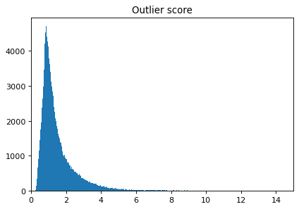

```python
plt.figure(figsize=(6, 4), dpi=80)
import matplotlib.pyplot as plt
plt.hist(y_train_scores, bins='auto')
plt.title("Outlier score")
plt.xlim(0,15)
plt.show()
```

#### The graph shows the distribution of outlier scores for the hospital billing dataset, where most billing records have low scores, indicating they are within normal ranges. The threshold of 3.792 is used to distinguish between normal and potential abnormal billing activities. Records with scores above this threshold are identified as outliers, which might indicate unusual billing practices, such as abnormally high charges in the billing amounts. The histogram shows that most billing records are typical, while a small number may represent abnormal pattern.

#### Present the descriptive statistics of the normal and the abnormal groups

```python
def descriptive_stat_threshold(X, scores, threshold):
    normal_mask = scores <= threshold
    anomaly_mask = scores > threshold

    normal_stats = X[normal_mask].describe()
    anomaly_stats = X[anomaly_mask].describe()

    summary_df = pd.DataFrame({
        'Group': ['Normal', 'Outlier'],
        'Count': [normal_mask.sum(), anomaly_mask.sum()],
        'Count %': [normal_mask.mean() * 100, anomaly_mask.mean() * 100]
    })
    feature_name=['Hospital_Average_Total_Payments','City_to_State_Payment_Ratio','Provider_to_State_Payment_Ratio', 'Hospital_to_State_Discharge_Ratio','City_to_State_Discharge_Ratio','Provider_to_State_Discharge_Ratio', 'Hospital_to_State_Medicare_Payment_Ratio','City_to_State_Medicare_Payment_Ratio','Provider_to_State_Medicare_Payment_Ratio']
    for i, feature in enumerate(feature_list, 1):
        summary_df[feature_name[i-1]] = [
            X[normal_mask][feature].mean(),
            X[anomaly_mask][feature].mean()
        ]


    summary_df['Anomaly_Score'] = [
        scores[normal_mask].mean(),
        scores[anomaly_mask].mean()
    ]
    summary_df=summary_df.T
    summary_df.columns = summary_df.iloc[0]
    summary_df=summary_df.iloc[1:]
    return summary_df
```

```python
threshold = atcdr.threshold_
feature_list = ['F1', 'F2', 'F3', 'F4', 'F5', 'F6', 'F7', 'F8', 'F9']
# Apply the function
descriptive_stat_threshold(X_train, y_train_scores, threshold)
```

| Group | Normal | Outlier |
| --- | --- | --- |
| Count | 123929 | 6523 |
| Count % | 94.999693 | 5.000307 |
| Hospital_Average_Total_Payments | 0.984707 | 1.297104 |
| City_to_State_Payment_Ratio | 0.992128 | 1.175979 |
| Provider_to_State_Payment_Ratio | 0.984707 | 1.297104 |
| Hospital_to_State_Discharge_Ratio | 0.023657 | 0.16686 |
| City_to_State_Discharge_Ratio | 0.062138 | 0.431725 |
| Provider_to_State_Discharge_Ratio | 0.023657 | 0.16686 |
| Hospital_to_State_Medicare_Payment_Ratio | 0.985096 | 1.290634 |
| City_to_State_Medicare_Payment_Ratio | 0.992976 | 1.166408 |
| Provider_to_State_Medicare_Payment_Ratio | 0.985096 | 1.290634 |
| Anomaly_Score | 1.339546 | 6.502766 |

#### In the total records, 123929 (around 95%) are classified as normal, while 6523 (around 5%) are identified as outliers, suggesting potential abnormal billing practices. The average values for each features are shown for both groups, and it is clear that the outlier group has significantly higher feature values across several key metrics, like the feature2 City_to_State_Payment_Ratio by DRG, feature3 Provider_to_State_Payment_Ratio by DRG, and feature5 City_to_State_Discharge_Ratio by DRG. These differences indicate that the outlier records deviate noticeably from the norm, highlighting abnormal billing patterns.

### Aggregating to achieve model stability

#### Using multiple autoencoder models to improve the stability of outlier detection by aggregating results. This aggregation reduces the sensitivity to variations in individual models and improves the overall reliability of detecting abnormal hospital billing patterns.

```python
from pyod.models.combination import aom, moa, average, maximization
from pyod.utils.utility import standardizer
from pyod.models.auto_encoder import AutoEncoder
atcdr1 = AutoEncoder(contamination=0.05, hidden_neuron_list =[2, 2])
atcdr2 = AutoEncoder(contamination=0.05, hidden_neuron_list =[10, 2, 10])
atcdr3 = AutoEncoder(contamination=0.05, hidden_neuron_list =[15, 10, 2, 10, 15] )

train_scores = np.zeros([X_train.shape[0], 3])
test_scores = np.zeros([X_test.shape[0], 3])
atcdr1.fit(X_train)
atcdr2.fit(X_train)
atcdr3.fit(X_train)

# Store the results
train_scores[:, 0] = atcdr1.decision_function(X_train)
train_scores[:, 1] = atcdr2.decision_function(X_train)
train_scores[:, 2] = atcdr3.decision_function(X_train)
test_scores[:, 0] = atcdr1.decision_function(X_test)
test_scores[:, 1] = atcdr2.decision_function(X_test)
test_scores[:, 2] = atcdr3.decision_function(X_test)

train_scores_norm, test_scores_norm = standardizer(train_scores,test_scores)

y_train_by_average = average(train_scores_norm)
y_test_by_average = average(test_scores_norm)
```

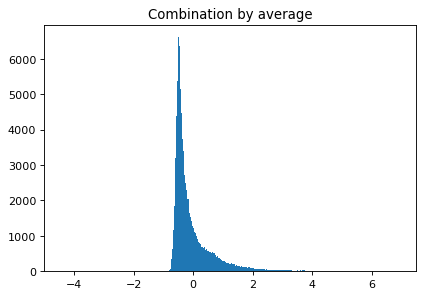

```python
import matplotlib.pyplot as plt
plt.figure(figsize=(6, 4), dpi=80)
plt.hist(y_train_by_average, bins='auto')
plt.title("Combination by average")
plt.xlim(-5,7.5)
plt.show()
```

#### The histogram shows the distribution of averaged anomaly scores after aggregating results from multiple models. The threshold of 1.5 is used to classify outliers. In the summary table below, 5% of the records are marked as outliers, with significantly higher average values for features, suggesting potential abnormal billings that differ from the typical patterns. For example, the Hospital_Average_Total_Payments and Provider_to_State_Payment_Ratio for outliers are around 1.4 times higher, indicating potential overpayments or unusual billing patterns. In addition, higher discharge ratios and Medicare payment ratios in outliers suggest irregularities in resource utilization.

```python
descriptive_stat_threshold(X_train,y_train_by_average, 1.5)
```

| Group | Normal | Outlier |
| --- | --- | --- |
| Count | 123897 | 6555 |
| Count % | 94.975163 | 5.024837 |
| Hospital_Average_Total_Payments | 0.980521 | 1.374707 |
| City_to_State_Payment_Ratio | 0.990036 | 1.214628 |
| Provider_to_State_Payment_Ratio | 0.980521 | 1.374707 |
| Hospital_to_State_Discharge_Ratio | 0.024551 | 0.149253 |
| City_to_State_Discharge_Ratio | 0.064461 | 0.386012 |
| Provider_to_State_Discharge_Ratio | 0.024551 | 0.149253 |
| Hospital_to_State_Medicare_Payment_Ratio | 0.979813 | 1.389009 |
| City_to_State_Medicare_Payment_Ratio | 0.990239 | 1.217285 |
| Provider_to_State_Medicare_Payment_Ratio | 0.979813 | 1.389009 |
| Anomaly_Score | -0.161528 | 3.053065 |

## Section 4: Using Isolation Forest

#### Isolation Forest is an algorithm that detects outliers by randomly cuts data into small pieces to see which points are stand out from the rest. It works by randomly splitting the data multiple times. Points that are easier to separate from others like outliers end up isolated faster. The algorithn assigns an anomaly score to each point, and those with higher scores are identifies as potential outliers.

```python
from pyod.models.iforest import IForest
isft = IForest(contamination=0.05, max_samples=40, behaviour='new')
isft.fit(X_train)

y_train_scores = isft.decision_function(X_train)
y_train_pred = isft.predict(X_train)

y_test_scores = isft.decision_function(X_test)
y_test_pred = isft.predict(X_test) # outlier labels (0 or 1)

print("The threshold for the defined contamination rate:" , isft.threshold_)

def count_stat(vector):
    unique, counts = np.unique(vector, return_counts=True)
    return dict(zip(unique, counts))

print("The training data:", count_stat(y_train_pred))
print("The testing data:", count_stat(y_test_pred))
```

```
The threshold for the defined contamination rate: -2.80533076965888e-17
The training data: {0: 123929, 1: 6523}
The testing data: {0: 31002, 1: 1611}
```

#### Determine a reasonable threshold

```python
isft.get_params()
```

```
{'behaviour': 'new',
 'bootstrap': False,
 'contamination': 0.05,
 'max_features': 1.0,
 'max_samples': 40,
 'n_estimators': 100,
 'n_jobs': 1,
 'random_state': None,
 'verbose': 0}
```

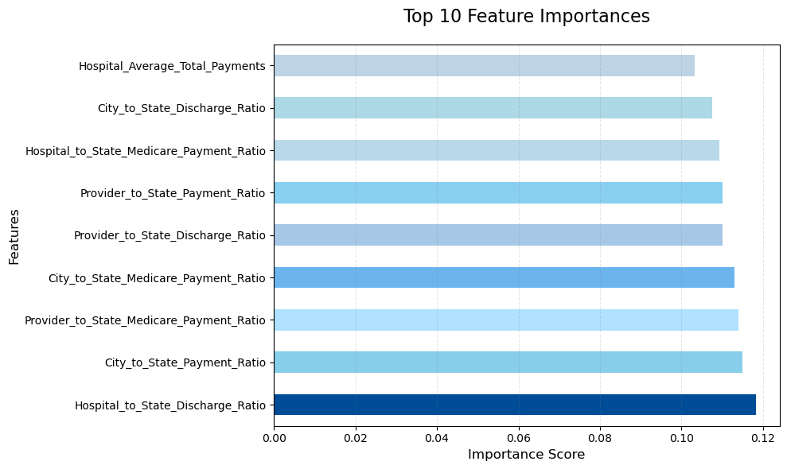

```python
isft_vi = isft.feature_importances_
colors = ['#004C97', '#87CEEB', '#B0E2FF', '#6CB4EE', '#A7C7E7',
          '#89CFF0', '#B9D9EB', '#ADD8E6', '#BCD4E6', '#C6E2FF']  # Different shades of blue
plt.figure(figsize=(10, 6))
feature_name=['Hospital_Average_Total_Payments','City_to_State_Payment_Ratio','Provider_to_State_Payment_Ratio', 'Hospital_to_State_Discharge_Ratio','City_to_State_Discharge_Ratio','Provider_to_State_Discharge_Ratio', 'Hospital_to_State_Medicare_Payment_Ratio','City_to_State_Medicare_Payment_Ratio','Provider_to_State_Medicare_Payment_Ratio']

importance_plot = (pd.Series(isft.feature_importances_, index=feature_name)
                    .nlargest(10)
                    .plot(kind='barh', color=colors))
plt.title('Top 10 Feature Importances', fontsize=16, pad=20)
plt.xlabel('Importance Score', fontsize=12)
plt.ylabel('Features', fontsize=12)
plt.grid(axis='x', linestyle='--', alpha=0.2, color='gray')
plt.gca().set_facecolor('white')
plt.tight_layout()
plt.show()
```

#### We can visualize feature importance in Isolation Forest to understand the contribution of each feature in the process of identifying outliers. I plot the feature importance scores, which represent the relative strength of each feature in determining outliers. The higher the score, the more significant the feature is in isolating outliers.

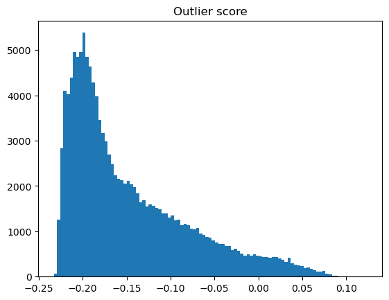

```python
import matplotlib.pyplot as plt
plt.hist(y_train_scores, bins='auto')
plt.title("Outlier score")
plt.show()
```

#### The graph shows the distribution of outlier scores generated by the isolation forest model, with most scores clustering around -0.2. The threshold is -2.8*e^17 which is near zero is used to separate normal data points from outliers.

#### Present the descriptive statistics of the normal and the abnormal groups

```python
threshold = isft.threshold_
feature_list = ['F1', 'F2', 'F3', 'F4', 'F5', 'F6', 'F7', 'F8', 'F9']
# Apply the function
descriptive_stat_threshold(X_train, y_train_scores, threshold)
```

| Group | Normal | Outlier |
| --- | --- | --- |
| Count | 123929 | 6523 |
| Count % | 94.999693 | 5.000307 |
| Hospital_Average_Total_Payments | 0.977957 | 1.425353 |
| City_to_State_Payment_Ratio | 0.987889 | 1.25651 |
| Provider_to_State_Payment_Ratio | 0.977957 | 1.425353 |
| Hospital_to_State_Discharge_Ratio | 0.025614 | 0.129672 |
| City_to_State_Discharge_Ratio | 0.068407 | 0.312613 |
| Provider_to_State_Discharge_Ratio | 0.025614 | 0.129672 |
| Hospital_to_State_Medicare_Payment_Ratio | 0.975345 | 1.475897 |
| City_to_State_Medicare_Payment_Ratio | 0.986749 | 1.284706 |
| Provider_to_State_Medicare_Payment_Ratio | 0.975345 | 1.475897 |
| Anomaly_Score | -0.155966 | 0.031024 |

#### The summary table shows the division of the hospital billing records into normal and outlier groups based on the isolation forest results. Approximately 5% of the records are classified as outliers, an their average feature values are generally much higher than those in the normal group, suggestig significant deviations. The anomaly score is higher for outlier which is 0.031 compared to the normal group which is -0.156, indicating that these records exhibit unusual billing patterns that may require further investigation.

#### Achieve Model Stability by Aggregating Multiple Models

#### Using mutiple isolation forest models with different numbers of estimators k_list to improve the stability of outlier detection. Each model is trained on the data, and outlier scores are calculates for both training and testing sets. The scores are then standardized to allow consistent comparison, aiming to achieve more reliable anomaly detection by combining results from multiple models.

```python
from pyod.models.combination import aom, moa, average, maximization
from pyod.utils.utility import standardizer
from pyod.models.iforest import IForest

k_list = [100, 200, 300, 400, 500]
n_clf = len(k_list)

train_scores = np.zeros([X_train.shape[0], n_clf])
test_scores = np.zeros([X_test.shape[0], n_clf])

# Modeling
for i in range(n_clf):
    k = k_list[i]
    isft = IForest(contamination=0.05, n_estimators=k)
    isft.fit(X_train)

    train_scores[:, i] = isft.decision_function(X_train)
    test_scores[:, i] = isft.decision_function(X_test)

train_scores_norm, test_scores_norm = standardizer(train_scores,test_scores)
```

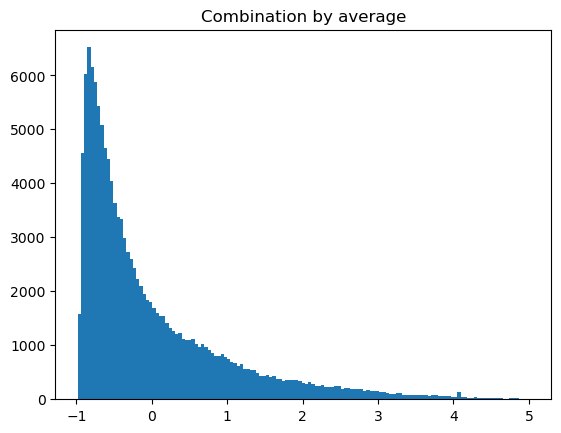

```python
# Combination by average
y_train_by_average = average(train_scores_norm)
y_test_by_average = average(test_scores_norm)
import matplotlib.pyplot as plt
plt.hist(y_train_by_average, bins='auto')
plt.title("Combination by average")
plt.show()
```

#### The graph shows the distribution of averaged outlier scores from multiple isolation forest models, with most scores clustered near -1, indicating typical hospital billings. The summary table shows that 5.1% of the records are classified as outliers, with significantly higher feature values compared to the normal records, which could be unusual billing activities. For example, the Hospital_Average_Total_Payments for outliers is over 1.3 times the normal value, suggesting potential overbilling or unusually high costs associated with specific cases.

```python
descriptive_stat_threshold(X_train,y_train_by_average, 2.15)
```

| Group | Normal | Outlier |
| --- | --- | --- |
| Count | 123823 | 6629 |
| Count % | 94.918437 | 5.081563 |
| Hospital_Average_Total_Payments | 0.983089 | 1.322333 |
| City_to_State_Payment_Ratio | 0.992759 | 1.161264 |
| Provider_to_State_Payment_Ratio | 0.983089 | 1.322333 |
| Hospital_to_State_Discharge_Ratio | 0.025382 | 0.132339 |
| City_to_State_Discharge_Ratio | 0.067662 | 0.322627 |
| Provider_to_State_Discharge_Ratio | 0.025382 | 0.132339 |
| Hospital_to_State_Medicare_Payment_Ratio | 0.982613 | 1.332142 |
| City_to_State_Medicare_Payment_Ratio | 0.993135 | 1.160661 |
| Provider_to_State_Medicare_Payment_Ratio | 0.982613 | 1.332142 |
| Anomaly_Score | -0.158325 | 2.957348 |